# OLS: Diagnostics

Rebecca Gill

2026-05-17

← Back to Index

This page is built in R Markdown. Most code chunks are hidden by default, but you can click ‘show’ to see the code that loads the libraries and generates the data, figures, and tables. The code is also available in my [studycourts/gradData GitHub repository](https://github.com/studycourts/gradData/tree/main/pages).

```r
P <- c("knitr",
       "kableExtra",   # prettier kable tables
       "tidyverse",    # ggplot2, dplyr, etc.
       "GGally",       # ggpairs() for bivariate matrix
       "stargazer",    # descriptive statistics tables
       "texreg",       # htmlreg() for regression tables
       "modelsummary", # compare_performance(), datasummary_skim()
       "performance",  # compare_performance()
       "ggeffects",    # ggpredict() for effects plots
       "patchwork",    # side-by-side ggplots
       "car",          # vif(), outlierTest(), crPlots(), influencePlot()
       "lmtest",       # resettest(), bptest()
       "sandwich",     # vcovHC() for HC-robust SEs
       "olsrr",        # ols_plot_dfbetas()
       "MASS",         # rlm() for robust regression
       "splines"       # ns() for natural cubic splines
       )

for (pkg in P) {
  if (!require(pkg, character.only = TRUE)) {
    install.packages(pkg, repos = "http://cran.us.r-project.org")
  }
  library(pkg, character.only = TRUE)
}
rm(P, pkg)  # clean up the mess
```

## Introduction

Every time you estimate an OLS regression model, you’re making a set of assumptions. The assumptions aren’t just bureaucratic fine print — when they’re violated, your coefficient estimates can be biased, your standard errors can be wrong, and your inferences can lead you astray. The goal of diagnostics is to find out *which* assumptions are violated, *how badly*, and *what to do about it*.

The problem is that the diagnostic steps can feel like a jumbled bag of tests and plots with no obvious logic connecting them. This document is my attempt to give you a clear, principled workflow — a sequence you can follow every single time you estimate an OLS model, with a rationale for *why* each step comes where it does.

Here’s the key logic:

> Some diagnostic problems contaminate others. Run diagnostics in the order that lets each step work on the cleanest possible version of your model.

This is why order matters. Unmodeled nonlinearity creates artificial outliers. Artificial outliers distort heteroscedasticity tests. Multicollinearity inflates standard errors in ways that look like estimation problems. Fix things in sequence, and the later diagnostics become more interpretable. Jump around, and you’ll be chasing ghosts.

## The Workflow at a Glance

Here’s the full sequence we’ll follow. Keep this table in mind as a roadmap; each step is covered in detail in the sections that follow.

Table 1: Table 2: The OLS Diagnostic Workflow

| Step | Stage | Key Tools | Why Here |
| --- | --- | --- | --- |
| 1 | Data Exploration | stargazer(), ggpairs(), t.test() | You must know your data before you can diagnose your model |
| 2 | Model Estimation | lm(), htmlreg() | You need a fitted model before you can examine its residuals |
| 3 | Multicollinearity | vif(), pairs.panels() | Collinearity is a design-matrix problem; diagnose it before residual checks |
| 4 | Nonlinearity | resettest(), crPlots(), poly(), ns() | Misspecified functional form creates phantom outliers and fake heteroscedasticity |
| 5 | Outliers & Influence | outlierTest(), cooks.distance(), influencePlot(), ols_plot_dfbetas() | With correct functional form, outliers are now real; diagnose and treat |
| 6 | Residual Normality | shapiro.test(), qqPlot() | Non-normality is often downstream of nonlinearity and outliers; check after fixing those |
| 7 | Heteroscedasticity | bptest(), ncvTest(), vcovHC(), rlm(), lm(log(y)) | Heteroscedasticity tests are most reliable once functional form is correct |
| 8 | Model Selection | anova(), compare_performance(), AIC/BIC | Compare baseline to corrected specifications using fit statistics |
| 9 | Presentation | htmlreg(), stargazer(), ggpredict() | Display your final, best-specified model with clean tables and effects plots |

Now let’s work through each step with a concrete example.

## The Data Generating Process

To make every diagnostic step interesting, I’ve built a dataset where *everything* is a little wrong. Here’s the true model:

$$y = 2 + 1.5x_1 + 3x_2 - 2x_2^2 + 0.8x_3 + \varepsilon_i$$

where:

- $x_1 \sim U(0, 10)$
- $x_2 \sim N(0, 1)$ — included in a *quadratic* relationship with $y$, which we’ll pretend not to know
- $x_3 = 0.7 \cdot x_1 + \eta$, $\eta \sim N(0, 1)$ — *correlated* with $x_1$, producing essential multicollinearity
- $\varepsilon_i \sim N(0, \sigma_i^2)$ where $\sigma_i = \exp(0.35 \cdot x_1)$ — *heteroscedastic* errors that fan out with $x_1$
- Three observations have been hand-placed as influential outliers

The model we’ll actually fit (pretending we don’t know the true DGP) is the misspecified version: $y = \beta_0 + \beta_1 x_1 + \beta_2 x_2 + \beta_3 x_3 + \varepsilon$. This gives us real problems to find and fix.

```r
set.seed(1975)

n   <- 300
x_1 <- runif(n, 0, 10)                         # uniform predictor
x_3 <- 0.7 * x_1 + rnorm(n, 0, 1)              # correlated with x_1 (multicollinearity)
x_2 <- rnorm(n, 0, 1)                          # nonlinear predictor
e   <- rnorm(n, 0, exp(0.35 * x_1))            # heteroscedastic errors

y   <- 2 + 1.5 * x_1 + 3 * x_2 - 2 * x_2^2 + 0.8 * x_3 + e

# build the data frame
sim.df <- data.frame(y, x_1, x_2, x_3)

# plant three influential outliers
sim.df[301, ] <- c(90, 9.5, 0.0, 8.0)   # high leverage, pulls line up
sim.df[302, ] <- c(-40, 8.5, 0.2, 7.5)  # high leverage, pulls line down
sim.df[303, ] <- c(200, 5.0, 0.1, 4.5)  # extreme Y outlier, high influence

n <- nrow(sim.df)  # update n to include planted outliers
```

## Step 1: Data Exploration

Before you touch `lm()`, look at your data. This isn’t just due diligence — it’s where you form hypotheses about what might go wrong. The questions to ask are: What are the distributions of each variable? Are there obvious outliers in the raw data? What are the bivariate relationships between predictors, and between each predictor and the outcome?

```r
stargazer(sim.df,
          title  = "Descriptive Statistics",
          type   = "html",
          format = "apsr",
          digits = 2)
```

**Descriptive Statistics**

| Statistic | N | Mean | St. Dev. | Min | Max |
| --- | --- | --- | --- | --- | --- |
| y | 303 | 11.34 | 19.42 | -40.00 | 200.00 |
| x_1 | 303 | 4.89 | 2.88 | 0.05 | 9.97 |
| x_2 | 303 | 0.01 | 1.07 | -2.93 | 3.53 |
| x_3 | 303 | 3.37 | 2.32 | -3.46 | 9.26 |

**Descriptive Statistics**

[output not shown]

Notice the range of `y` — the max is suspiciously large (200). This is a flag worth keeping in mind.

For continuous predictors, a scatter matrix showing bivariate relationships is worth its weight in gold. It lets you see both the correlation structure among your predictors *and* hints at nonlinearity in the predictor-outcome relationships.

Figure 1: Scatter matrix with Pearson correlations (upper triangle), bivariate smoothers (lower triangle), and density plots (diagonal).

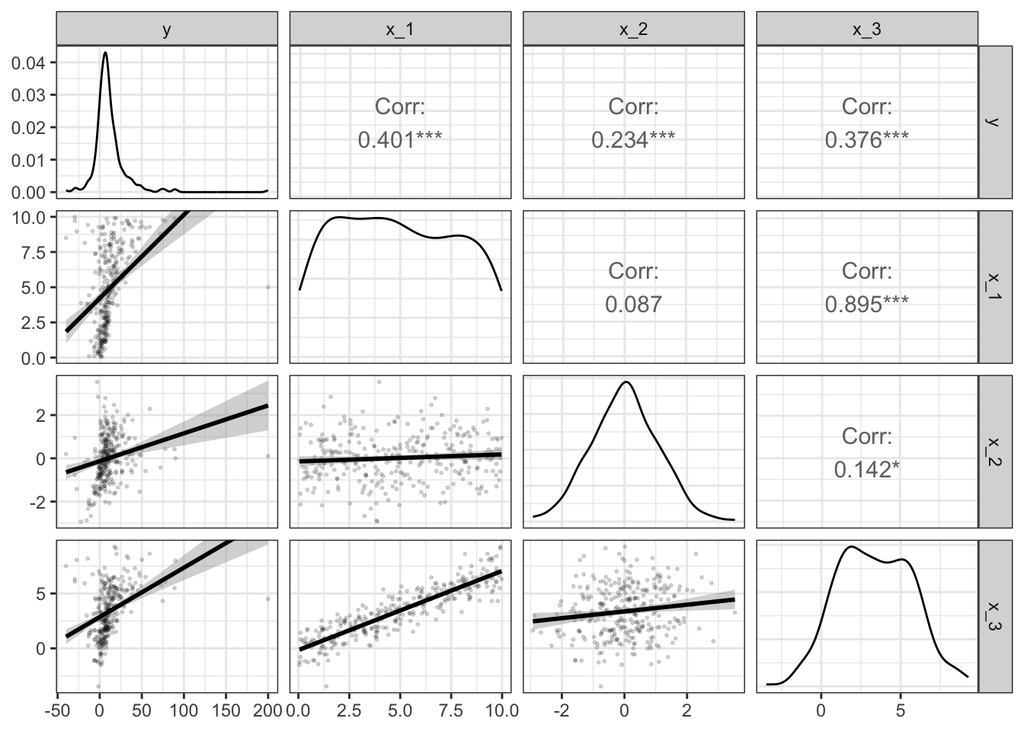

```r
sim.df %>%
  ggpairs(
    lower = list(continuous = wrap("smooth", alpha = 0.15, size = 0.4)),
    upper = list(continuous = wrap("cor", size = 4)),
    diag  = list(continuous = wrap("densityDiag", alpha = 0.4))
  ) +
  theme_bw(base_size = 11)
```

File these observations away. They’ll come back at every diagnostic step.

## Step 2: Model Estimation

Now we fit our baseline model. This is the model *as if we didn’t know about any of the problems* — it’s the starting point, not the ending point.

```r
ols.base <- lm(y ~ x_1 + x_2 + x_3,
               data = sim.df)

# uncomment to check in RStudio editor:
# screenreg(ols.base)

htmlreg(ols.base,
        format        = "apsr",
        caption       = "Baseline OLS Model (Misspecified)",
        caption.above = TRUE,
        single.row    = TRUE)
```

Baseline OLS Model (Misspecified)

|  | Model 1 |
| --- | --- |
| (Intercept) | -1.33 (1.99) |
| x_1 | 2.43 (0.79)** |
| x_2 | 3.61 (0.95)*** |
| x_3 | 0.21 (0.98) |
| R<sup>2</sup> | 0.20 |
| Adj. R<sup>2</sup> | 0.19 |
| Num. obs. | 303 |

***p < 0.001; **p < 0.01; *p < 0.05

Before we trust a single one of these coefficients, we need to run diagnostics. The quick four-plot suite gives us an initial read:

Figure 2: Baseline diagnostic plots. Several problems are already visible.

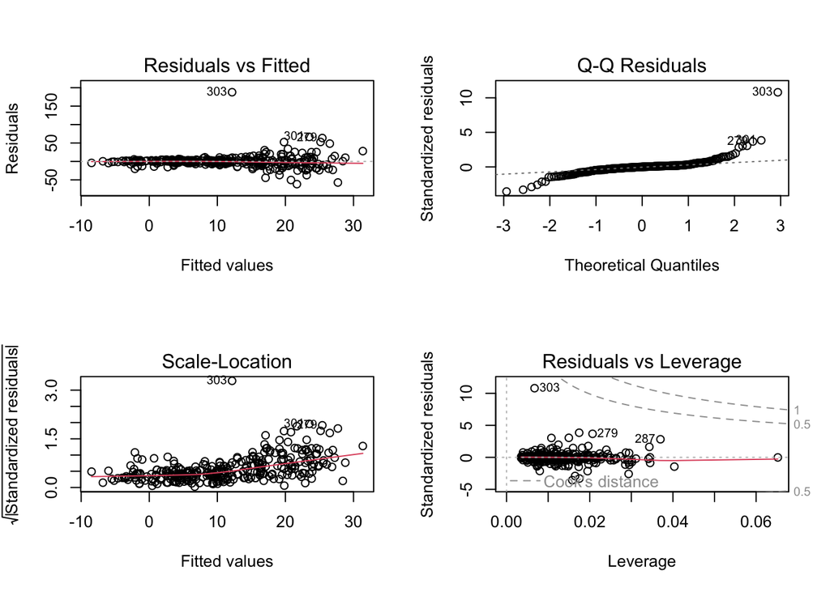

```r
par(mfrow = c(2, 2))
plot(ols.base)
```

## Step 3: Multicollinearity

We check multicollinearity *before* looking at residuals because it’s a structural property of the design matrix, not a residual-based problem. High multicollinearity inflates standard errors and can make coefficient estimates look unstable in ways that have nothing to do with your functional form or your error distribution. It’s cleaner to deal with this before you start interpreting the residual plots.[^1]

The gold standard diagnostic is the Variance Inflation Factor (VIF). Recall that $\text{VIF}_k = \frac{1}{1 - R^2_{x_k | x_{-k}}}$, where $R^2_{x_k | x_{-k}}$ is the $R^2$ from regressing predictor $k$ on all other predictors. A VIF above 5 or 10 is a common rule of thumb for concern.

```r
kable(vif(ols.base),
      col.names = c("VIF"),
      caption   = "Variance Inflation Factors, Baseline Model",
      digits    = 2) %>%
  kable_styling(full_width = FALSE)
```

Table 3: Table 4: Variance Inflation Factors, Baseline Model

|  | VIF |
| --- | --- |
| x_1 | 5.06 |
| x_2 | 1.03 |
| x_3 | 5.13 |

OK so the VIFs are high. What do I actually *do* about this?

You have a few options. The most theoretically motivated choice is usually to **drop one of the collinear variables** if they’re genuinely measuring the same underlying concept — keeping both in the model just adds noise. If you have theoretical reasons to believe both variables matter, you can sometimes **combine them** into a single composite (e.g., via a mean index or PCA). A third option is to **leave them both in** and acknowledge that your standard errors are inflated — this is defensible if your goal is prediction rather than causal inference from individual coefficients, or if dropping either would introduce omitted variable bias.

In this example, $x_1$ and $x_3$ come from different parts of the true model, so we’ll keep both for now and treat the inflated SEs as the cost of controlling for both. In your own work, the right choice depends on your theory. For more, see [my deep dive into multicollinearity](https://studycourts.github.io/gradData/multicollinearity.html).

## Step 4: Nonlinearity

Nonlinearity is the most important diagnostic to run *before* outliers and heteroscedasticity, because misspecified functional form creates both of them artificially. A variable that has a U-shaped relationship with $y$ will look like a fan in the scale-location plot and will generate residuals that look like outliers near the extremes of $x$. Fix the functional form first, then re-examine.

```r
resettest(ols.base, type = "regressor")
```

```
##
##  RESET test
##
## data:  ols.base
## RESET = 2.3, df1 = 6, df2 = 293, p-value = 0.04
```

Figure 3: Component-plus-residual plots. The curvature in x_2 is the clearest signal of nonlinearity.

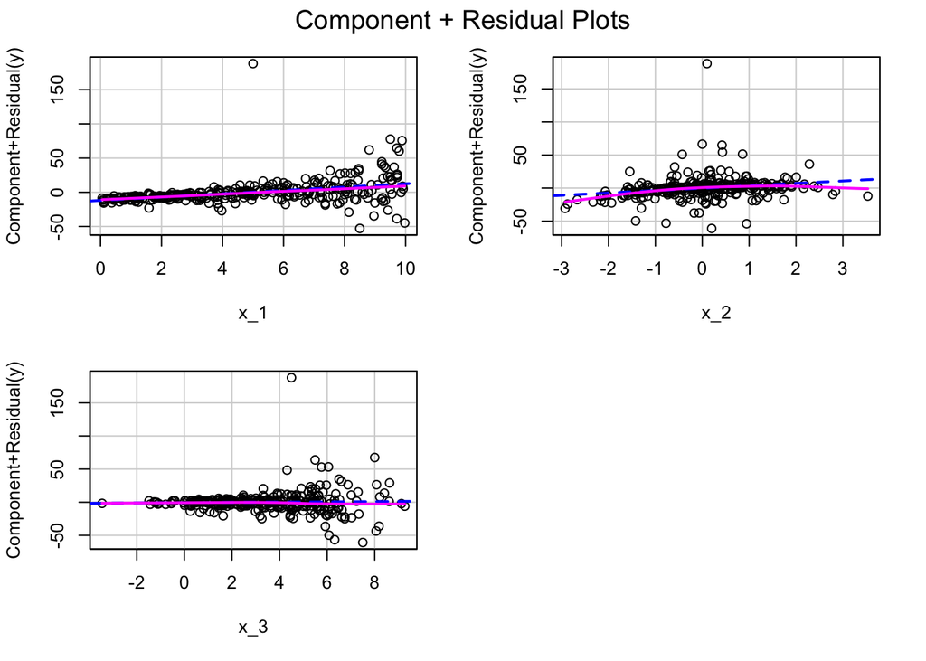

```r
crPlots(ols.base,
        terms = ~ x_1 + x_2 + x_3)
```

```r
ols.poly <- lm(y ~ x_1 + poly(x_2, 2, raw = TRUE) + x_3,
               data = sim.df)

htmlreg(ols.poly,
        format        = "apsr",
        caption       = "OLS Model with Quadratic Term for x_2",
        caption.above = TRUE,
        single.row    = TRUE)
```

OLS Model with Quadratic Term for x_2

|  | Model 1 |
| --- | --- |
| (Intercept) | 1.27 (2.12) |
| x_1 | 2.23 (0.78)** |
| poly(x_2, 2, raw = TRUE)1 | 3.78 (0.94)*** |
| poly(x_2, 2, raw = TRUE)2 | -1.94 (0.60)** |
| x_3 | 0.39 (0.97) |
| R<sup>2</sup> | 0.23 |
| Adj. R<sup>2</sup> | 0.22 |
| Num. obs. | 303 |

***p < 0.001; **p < 0.01; *p < 0.05

```r
resettest(ols.poly, type = "regressor")
```

```
##
##  RESET test
##
## data:  ols.poly
## RESET = 0.57, df1 = 8, df2 = 290, p-value = 0.8
```

The RESET test no longer rejects. Let’s confirm visually:

Figure 4: CR plots after adding the quadratic term. The curvature in x_2 is now gone.

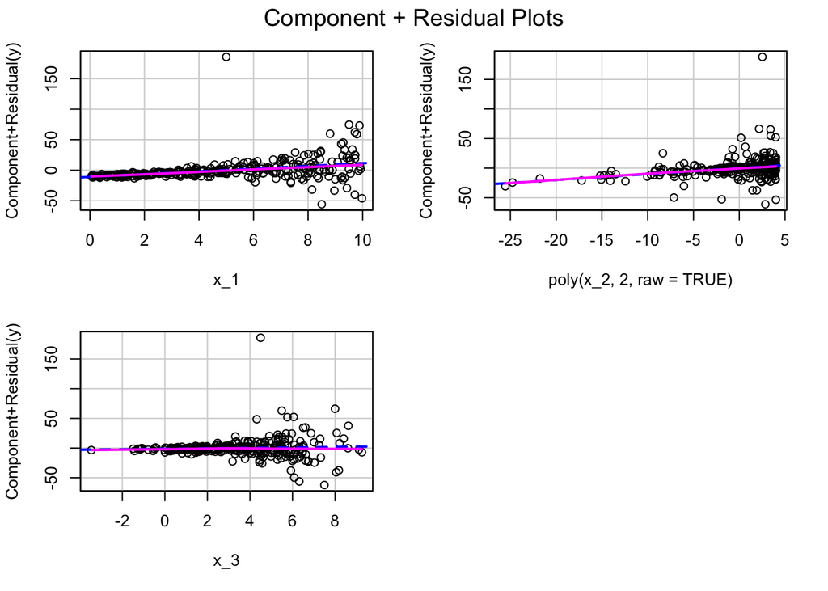

```r
crPlots(ols.poly)
```

The nonlinearity is resolved. We now use `ols.poly` as our working model for all subsequent diagnostics.

## Step 5: Outliers and Influence

With the correct functional form in place, we can now assess whether any observations are unduly influencing our estimates. There are three types of outliers worth distinguishing:[^3]

- **Regression outliers** — observations with large residuals (far from the fitted line on $y$)
- **High leverage points** — observations with extreme predictor values (far from the center of the $x$ space)
- **Influential observations** — high leverage points that also have large residuals; they actually *pull* the regression line toward them

The **studentized residuals** with a Bonferroni correction (`car::outlierTest()`) gives us a formal test for the most extreme residuals:

```r
car::outlierTest(ols.poly)
```

```
##     rstudent                      unadjusted p-value
## 303   13.897 0.0000000000000000000000000000000003612
## 301    3.870 0.0001338099999999999944848283472964567
## 302   -3.833 0.0001544799999999999981763892931141413
##                             Bonferroni p
## 303 0.0000000000000000000000000000001094
## 301 0.0405459999999999987085885777560179
## 302 0.0468070000000000013828937994730950
```

We’ve identified a handful of observations with large studentized residuals. Now let’s see which ones are actually *influential* — meaning they’re not just large residuals, but they’re also pulling hard on the regression line. The tool for this is **Cook’s Distance**, which measures how much the fitted values would change if we deleted each observation. The conventional cutoff is $4/(n - k - 1)$.

Figure 5: Cook’s Distance plot. Observations above the cutoff are worth investigating.

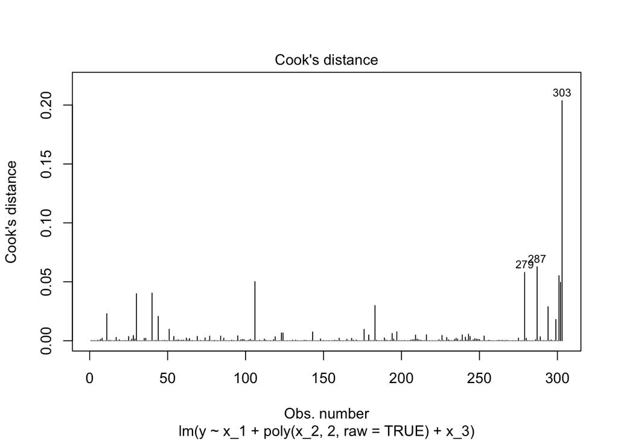

```r
cutoff <- 4 / (nrow(sim.df) - length(ols.poly$coefficients) - 2)
plot(ols.poly, which = 4, cook.levels = cutoff)
```

Figure 6: Influence plot. Large bubbles in the upper- or lower-right corner indicate truly influential observations.

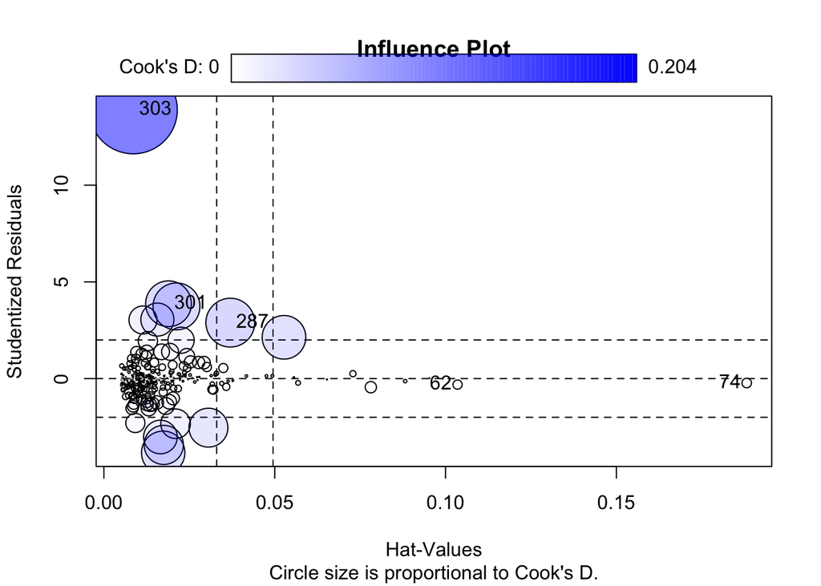

```
##     StudRes     Hat    CookD
## 62  -0.3101 0.10351 0.002227
## 74  -0.2274 0.18816 0.002404
## 287  2.8932 0.03700 0.062773
## 301  3.8700 0.01891 0.055150
## 303 13.8973 0.00860 0.203734
```

```r
influencePlot(ols.poly,
              main = "Influence Plot",
              sub  = "Circle size is proportional to Cook's D.")
```

Figure 7: DFBETAS plots. Values beyond the dashed lines indicate observations that substantially shift a specific coefficient.

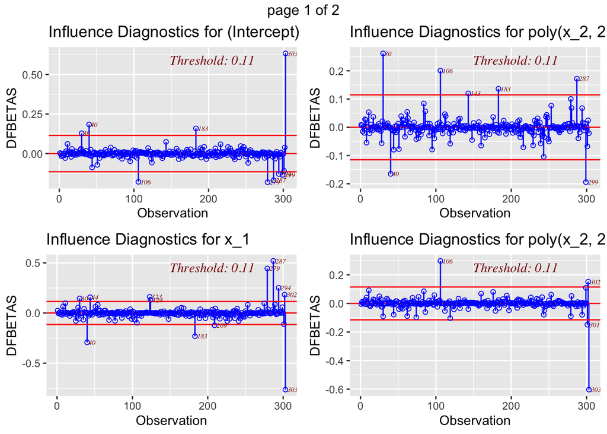

Figure 8: DFBETAS plots. Values beyond the dashed lines indicate observations that substantially shift a specific coefficient.

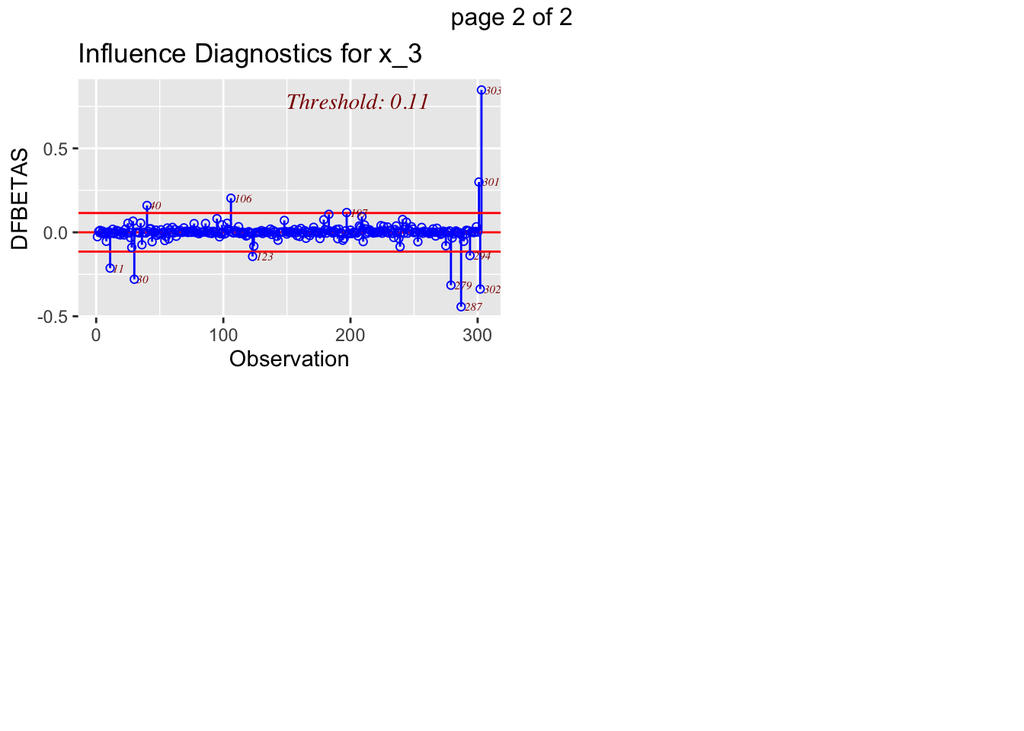

```r
ols_plot_dfbetas(ols.poly)
```

These three observations are clearly problematic. Do I just drop them?

Not necessarily — and not automatically. The right question to ask first is *why* is each observation extreme? If it’s a data entry error (a code of 999 where 1–5 was intended, or a decimal point in the wrong place), drop it and fix your data. If it’s a valid but unusual case, you have more options: you can **dummy it out** (add an indicator variable that is 1 for that observation and 0 for all others, which absorbs its effect without discarding the information), you can **use robust regression** to downweight it, or you can **acknowledge and retain it** with a footnote explaining why.

In this example, our three planted outliers are clearly artificial, so we’ll proceed by removing them to show you the clean workflow. In your own research, be conservative — dropping valid observations without justification is a form of data manipulation. Your other options are discussed in more depth in this [deep dive into outliers](https://studycourts.github.io/gradData/outliers.html).

```r
# remove the three planted outliers
sim.clean <- sim.df[-c(301, 302, 303), ]

# re-estimate the model on the cleaned data
ols.clean <- lm(y ~ x_1 + poly(x_2, 2, raw = TRUE) + x_3,
                data = sim.clean)
```

## Step 6: Residual Normality

OLS doesn’t require normally distributed errors for the coefficient estimates to be unbiased — but it does require it for our confidence intervals and hypothesis tests to be exactly correct in small samples. In large samples, the Central Limit Theorem gives us approximate normality of the sampling distribution regardless, so this assumption is less pressing with more data. Still, it’s worth checking.

The two standard tools are the **Q-Q plot** (visual) and the **Shapiro-Wilk test** (formal):

Figure 9: Q-Q plot of studentized residuals. Points following the dashed line indicate normality.

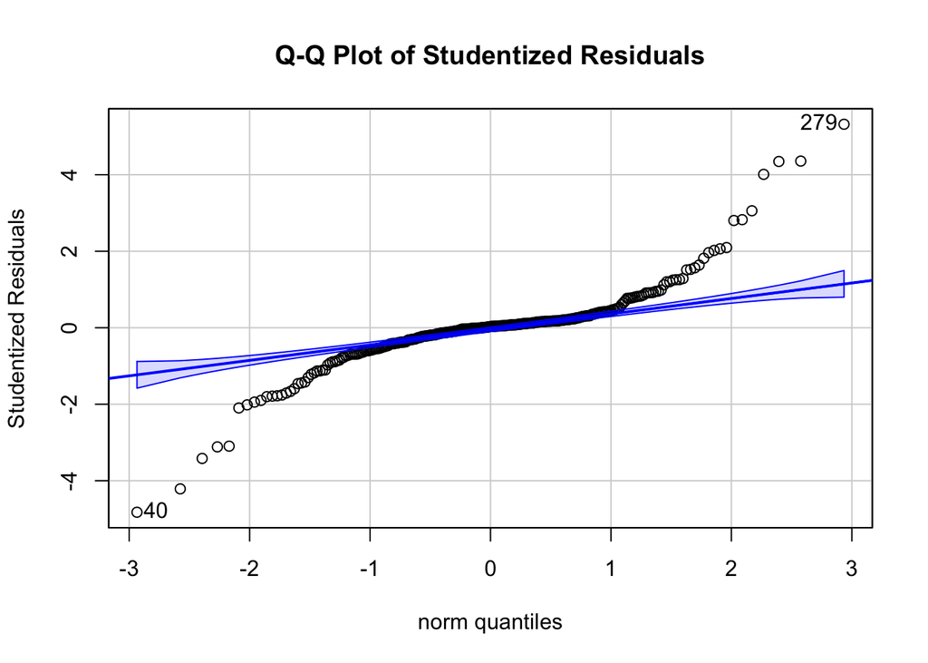

```
## [1] 279  40
```

```r
res.clean <- rstudent(ols.clean)
car::qqPlot(res.clean,
            main = "Q-Q Plot of Studentized Residuals",
            ylab = "Studentized Residuals")
```

```r
shapiro.test(rstandard(ols.clean))
```

```
##
##  Shapiro-Wilk normality test
##
## data:  rstandard(ols.clean)
## W = 0.84, p-value <0.0000000000000002
```

My Shapiro-Wilk test is significant. Should I panic?

Probably not. A few things are worth remembering here. First, in large samples, Shapiro-Wilk is so sensitive that it will reject for trivially small departures from normality that have essentially no impact on your inferences. Second, non-normality in the residuals can itself be a *symptom* of problems you’ve already fixed — outliers and nonlinearity both distort the residual distribution. If your Q-Q plot shows only mild departures in the tails (not a systematic curve or heavy skew), you’re usually fine to proceed. If the Q-Q plot is badly curved or the residuals are highly skewed, you might consider a transformation of $y$ (we’ll see this option again in the heteroscedasticity section).

## Step 7: Heteroscedasticity

Heteroscedasticity means the variance of the errors is not constant — it varies systematically across the range of the predictors or fitted values. OLS remains unbiased in its coefficient estimates under heteroscedasticity, but the standard errors become unreliable. They can be too big *or* too small, with no way to know which without further investigation. That’s an inference problem.

**Visual diagnosis first.** The scale-location plot from `plot(model)` is the key one — you’re looking for a flat horizontal line with roughly equal spread. The residuals-vs-fitted plot helps too.

Figure 10: Diagnostic plots after removing outliers and correcting nonlinearity. The fanning in the scale-location plot is the heteroscedasticity signal.

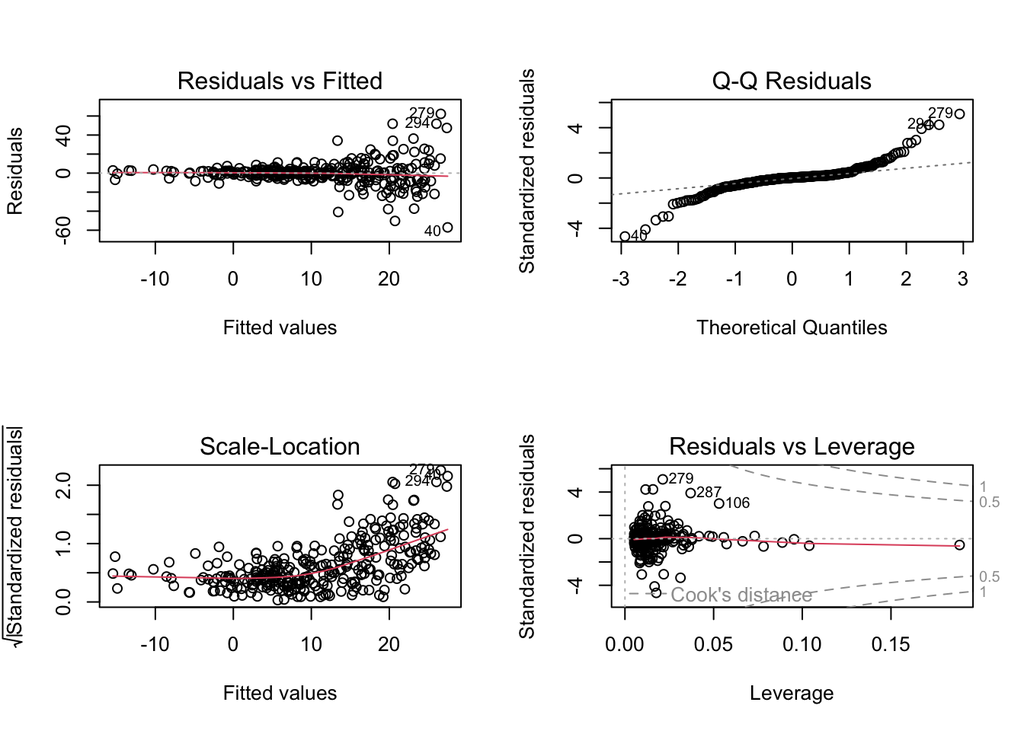

```r
par(mfrow = c(2, 2))
plot(ols.clean)
```

The fanning in the scale-location plot (bottom left) is unmistakeable. Now let’s confirm with formal tests. The **Breusch-Pagan test** regresses the squared residuals on the predictors; rejection means at least one predictor is linearly associated with the error variance. The **White test** extends this to include squared terms and cross-products, making it sensitive to nonlinear variance structures as well. The **Goldfeld-Quandt test** splits the data into two groups based on a predictor (often the one suspected of driving heteroscedasticity) and tests whether the variance of the residuals differs between them.

```r
# Breusch-Pagan test
bptest(ols.clean)
```

```
##
##  studentized Breusch-Pagan test
##
## data:  ols.clean
## BP = 59, df = 4, p-value = 0.000000000005
```

```r
# White test using fitted values and their square
sim.clean$fitted.clean <- fitted(ols.clean)
bptest(ols.clean,
       ~ fitted.clean + I(fitted.clean^2),
       data = sim.clean)
```

```
##
##  studentized Breusch-Pagan test
##
## data:  ols.clean
## BP = 68, df = 2, p-value = 0.000000000000002
```

```r
# Goldfeld-Quandt test, splitting on x_1, x_2, x_3
lmtest::gqtest(ols.clean, order.by = ~ x_1, data = sim.clean)
```

```
##
##  Goldfeld-Quandt test
##
## data:  ols.clean
## GQ = 34, df1 = 145, df2 = 145, p-value <0.0000000000000002
## alternative hypothesis: variance increases from segment 1 to 2
```

```r
lmtest::gqtest(ols.clean, order.by = ~ x_2, data = sim.clean)
```

```
##
##  Goldfeld-Quandt test
##
## data:  ols.clean
## GQ = 1.3, df1 = 145, df2 = 145, p-value = 0.05
## alternative hypothesis: variance increases from segment 1 to 2
```

```r
lmtest::gqtest(ols.clean, order.by = ~ x_3, data = sim.clean)
```

```
##
##  Goldfeld-Quandt test
##
## data:  ols.clean
## GQ = 27, df1 = 145, df2 = 145, p-value <0.0000000000000002
## alternative hypothesis: variance increases from segment 1 to 2
```